[figure not shown]

## Primera Escuela de Computación Cuántica

Autores: Fernando Martínez García\ Institución: Instituto de Física Fundamental, CSIC\ Correo: f.martinez@iff.csic.es

# Introducción a la corrección de errores cuánticos

### Laboratorio Computacional

## Outline

1. Código de 3 qubits
2. Código de Steane

## 1. Código de 3 qubits

En este ejercicio nos vamos a familiarizar con las ideas básicas de QEC usando como ejemplo un código de 3 qubits como el que se ha visto en la clase de teoría. Para ello, usaremos Qiskit. Empezamos importando los paquetes que vamos a necesitar:

Se nos piden las siguientes tareas:

1. Construir el circuito para codificar el estado de un qubit físico usando el código de 3 qubits.
2. Construir los circuitos para medir los estabilizadores.
3. Introduce un error $X$ en uno de los qubits del código y mide los estabilizadores. Usando estas medidas, ¿puedes deducir en que qubit ocurrió el error?.
4. Si el error que ocurre es de tipo $Z$ en vez de $X$, ¿es posible detectarlo usando este código de 3 qubits?
5. Realiza simulaciones introduciendo errores de tipo $X$ en cada qubit con probabilidad $p$ (la misma para cada qubit). Repitelo para diferentes valores de $p$ para obtener el threshold de este código para este modelo de errores. Compara estos resultados con los obtenidos analiticamente.

### Construir el circuito para codificar el estado de un qubit físico arbitrario usando el código de 3 qubits.

En la clase de teoría hemos visto que el circuito para codificar un estado de un qubit arbitrario $|\psi\rangle$ usando el código de 3 qubits. En este caso vamos a codificar el estado $|\psi\rangle=\frac{1}{\sqrt{2}}(|0\rangle -|1\rangle)$. Este viene dado por:

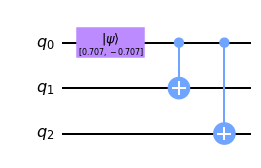

Este circuito crea el estado $|\psi\rangle=\frac{1}{\sqrt{2}}(|000\rangle -|111\rangle)$

### Construir los circuitos para medir los estabilizadores

Los estabilizadores del código de 3 qubits consisten en medidas de la paridad entre parejas de qubits. En este caso vamos a seleccionar medidas $Z_1Z_2$ y $Z_2Z_3$. La estructura de estos dos estabilizadores es la misma, diferenciandose solamente en los qubits sobre los que actúan. Debido a esto, cada uno va a consistir en un bloque de 3 qubits (2 del código y 1 anzilla) como el siguiente:

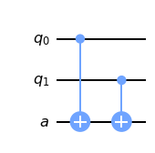

Con esta estructura para los estabilizadores, podemos pasar a definir el circuito completo para el código de 3 qubits. Este consistira en 3 qubits del código, 2 qubits anzilla para medir los estabilizadores, y 2 bits clásicos para guardar el resultado de cada estabilizador. A este circuito le podemos añadir estabilizadores como el anterior para realizar medidas de la paridad:

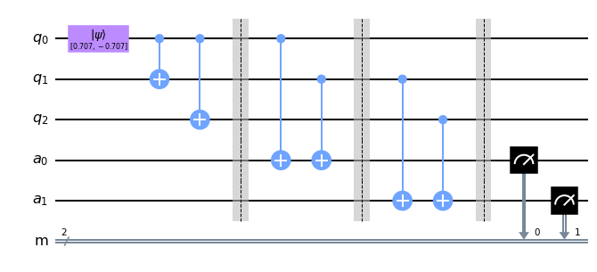

Con esto ya tenemos un circuito que mide los estabilizadores del código de 3 qubits. Podemos simular este circuito para medir los estabilizadores:

```
Results: {'00': 1024}
```

Como era de esperar, al evaluar las paridades del estado codificado (superposición de $|000\rangle$ y $|111\rangle$), medimos cada uno de los estabilizadores en $0$.

### Introduce un error $X$ en uno de los qubits del código y mide los estabilizadores.

Introduzcamos un error X en el primer qubit y veamos como se comporta el circuito anterior:

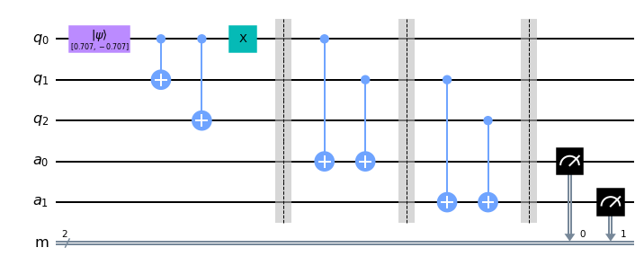

Realizando las simulaciones obtenemos:

```
Results: {'01': 1024}
```

### Usando estas medidas, ¿puedes deducir en que qubit ocurrió el error?.

Teniendo en cuenta que Qiskit ordena los bits de derecha a izquierda, todas las medidas del primer qubit anzilla han sido $1$ mientras que las del segundo han sido $0$. Considerando la tabla de sindromes del código de 3 qubits, el código asume que el error ha ocurrido en el primer qubit, que en efecto es el qubit que ha sufrido el error.

### Si el error que ocurre es de tipo $Z$ en vez de $X$, ¿es posible detectarlo usando este código de 3 qubits?

Podemos utilizar el código de Qiskit anterior para ver que ocurre en este caso. Simplemente tenemos que cambiar el error $X$ por uno $Z$:

```
Results: {'00': 1024}
```

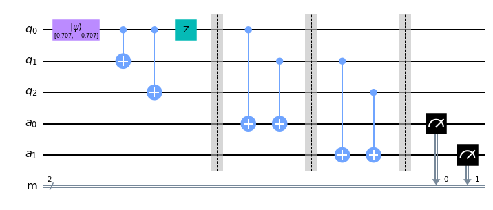

Como podemos ver, este código no es capaz de detectar errores de tipo $Z$. Esto motiva el desarrollo de códigos de corrección de errores cuánticos más complejos como los que hemos visto en la clase de teoría y que desarrollaremos en detalle en el Ejercicio 2.

### Realiza simulaciones introduciendo errores de tipo $X$ en cada qubit con probabilidad $p$ (la misma para cada qubit)

Podemos configurar nuestro código de Qiskit para añadir un error de tipo $X$ a cada qubit con probabilidad $p$. En el siguiente ejemplo, utilizamos $p=0.3$:

```
Error original: [0, 0, 0]
Corrección: [0, 0, 0]
Error corregido!
```

Este proceso se puede repetir muchas veces para obtener una estadística. Repitiendo este proceso para diferentes valores de $p$ se puede obtener el threshold de este código. Primero obtenemos las probabilidades de error lógico dado una probabilidad $p$ de error físico para diferentes valores de $p$:

Usando estos valores, podemos obtener el threshold de este código para este modelo de errores con solo errores de tipo $X$. Este comportamiento de la probabilidad de error lógico como función de la probabilidad de error físico se puede calcular también de forma analítica teniendo en cuenta que este código siempre funciona cuando no hay errores o hay un error, y siempre falla si hay 2 o 3 errores. Teniendo esto en cuenta, la probabilidad de error lógico es: \begin{equation} p_L = 1- \sum_{n=0}^1\binom{3}{n} p^n(1-p)^{3-n}= 3p^2-2p^3 \end{equation}

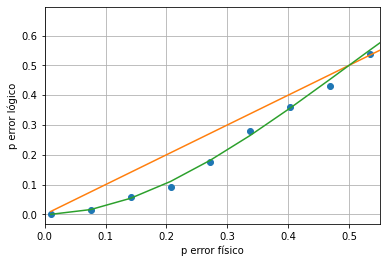

En este ejercicio nos vamos a familiarizar con las ideas básicas del código de Steane como se ha visto en la clase de teoría:

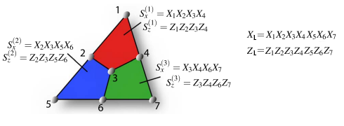

Para ello, usaremos Qiskit. Empezamos importando los paquetes que vamos a necesitar:

Para este ejercicio, aportamos el código para inicializar el estado $|0_L\rangle$ del código de Steane:

Podemos dibujar este circuito:

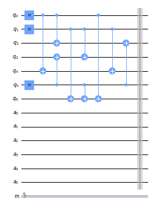

Se nos piden las siguientes tareas:

### Define los subcircuitos encargados de obtener las medidas de los estabilizadores $S_z^{(1)}$, $S_z^{(2)}$ y $S_z^{(3)}$.

Las medidas de los estabilizadores $S_z^{(1)}$, $S_z^{(2)}$ y $S_z^{(3)}$ comparten una estructura similar entre ellas y con la medida de los estabilizadores que ya hemos visto en el Ejercicio 1. Por tanto, podemos definir una función general para estas medidas:

Podemos probar esta función para el estabilizador $S_z^{(1)}$:

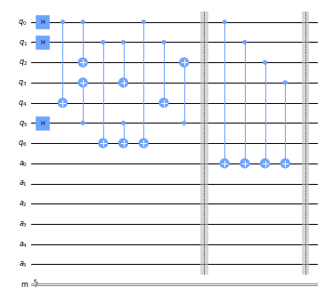

### Define los subcircuitos encargados de obtener las medidas de los estabilizadores $S_x^{(1)}$, $S_x^{(2)}$ y $S_x^{(3)}$.

Ya sabemos como realizar medidas de estabilizadores como los $S_z^{(1)}$, pero medir estabilizadores como $S_x^{(1)}$ puede ser menos intuitivo. Esto se puede conseguir utilizando puertas Hadamard para rotar la base $Z$ en la base $X$. Teniendo esto en cuenta se puede llegar a que un estabilizador de este tipo se puede medir usando una combinación de la medida de los estabilizadores $Z$ anteriores y puertas Hadamard:

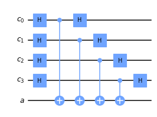

Se puede simplificar el proceso de medida de estos estabilizadores reduciendo el número de puertas involucradas. Para esto se puede tener en cuenta que el circuito:

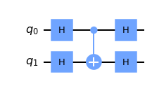

Es equivalente al siguiente circuito:

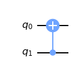

Teniendo en cuenta esto, obtén un circuito simplificado para la medida de los estabilizadores $S_x^{(1)}$, $S_x^{(2)}$ y $S_x^{(3)}$.

Teniendo en cuenta las pistas anteriores, se puede usar el circuito dado para medir los estabilizadores $X$ y modificarlo a base de quitar las puertas Hadamard a los lados de los qubits del código y añadirlas al principio y al final del circuito del qubit anzilla. También hay que cambiar el control de la puerta CNOT por el objetivo. Teniendo esto en cuenta, las medidas de los estabilizadores $S_x^{(1)}$, $S_x^{(2)}$ y $S_x^{(3)}$ comparten una estructura similar. Por tanto, podemos definir una función general para definir estas medidas:

Podemos probar esta función para el estabilizador $S_x^{(1)}$:

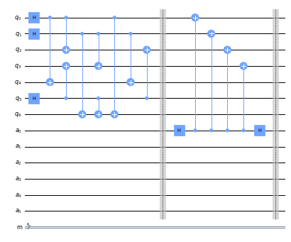

Con estas funciones podemos definir el circuito que inicializa el estado $|0_L\rangle$ y realiza medidas de los estabilizadores:

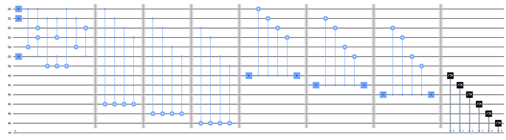

### Define una función que, dados los resultados de las medidas de los estabilizadores, te devuelva que corrección hay que hacer.

Primero modificamos el código anterior para incluir la simulación y que nos devuelva el resultado de las medidas:

```
Medidas de los estabilizadores: 000000
```

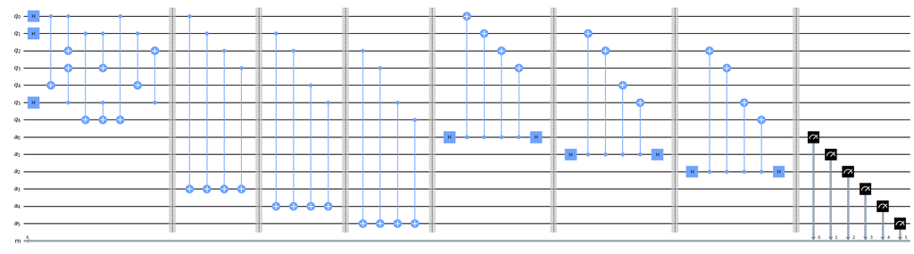

Ahora podemos definir una función que tome el resultado de medir los estabilizadores y proponga una corrección:

Podemos añadir esta función al final de nuestro código anterior, lo cual completa la corrección de errores. Podemos comprobar que nuestro código es capaz de corregir hasta un error de tipo $X$ y uno de tipo $Z$ ocurriendo a la vez:

```
Medidas de los estabilizadores: 011101
```

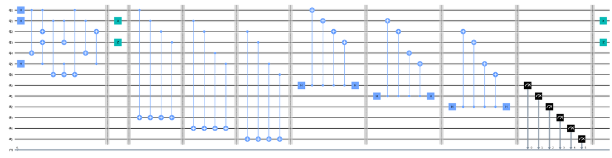

### En el caso de que ocurriesen dos errores del mismo tipo, $X$ por ejemplo, en dos qubits diferentes, ¿sería capaz de corregirlo el código de Steane?

Podemos utilizar el código anterior para generar dos errores de tipo $X$. En este caso los situamos en los dos primeros qubits:

```
Medidas de los estabilizadores: 010000
```

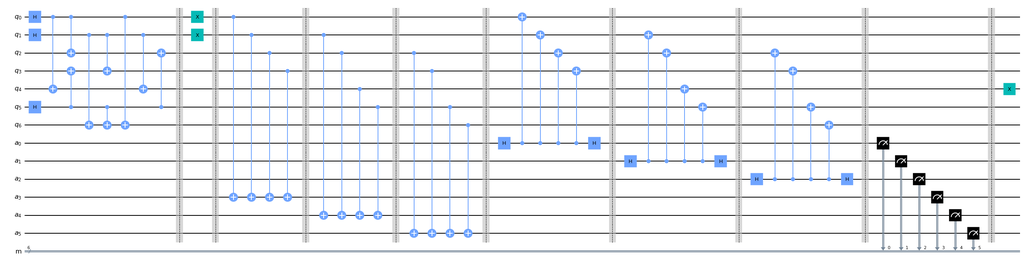

Para que el código de Steane corrija los errores, tiene que ocurrir una de dos posibilidades: 1) La corrección sugerida por el código es igual al error, o 2) La combinación del error y la corrección son equivalentes a una combinación de estabilizadores.

Con respecto a la primera posibilidad, viendo la tabla de correcciones del código, podemos ver que la corrección sugerida por el código de Steane es como mucho una puerta de cada tipo. Es decir, si ocurren 2 errores del mismo tipo, la corrección no va a poder suprimir estos dos errores.

Con respecto a la segunda, la combinación de un error del mismo tipo en 2 qubits diferentes junto a la corrección (que como ya hemos dicho, será solo en 1 qubit), puede ser como mucho una operación en 3 qubits, mientras que los estabilizadores son operadores en 4 qubits. Por tanto, esta posibilidad tampoco se puede dar con un error del mismo tipo en 2 qubits.

### Suponiendo que la medida de, por ejemplo, el estabilizador $S_x^{(3)}$ fuese la última del circuito, ¿que ocurriría si apareciese un error $X$ en el qubit anzilla justo antes de la penúltima puerta CNOT?¿Puede el código que hemos preparado en este ejercicio corregir errores que aparecen durante el proceso de corrección?

Para completar este apartado, es conveniente tener en cuenta las reglas de propagación de errores que hemos visto en la clase de teoría:

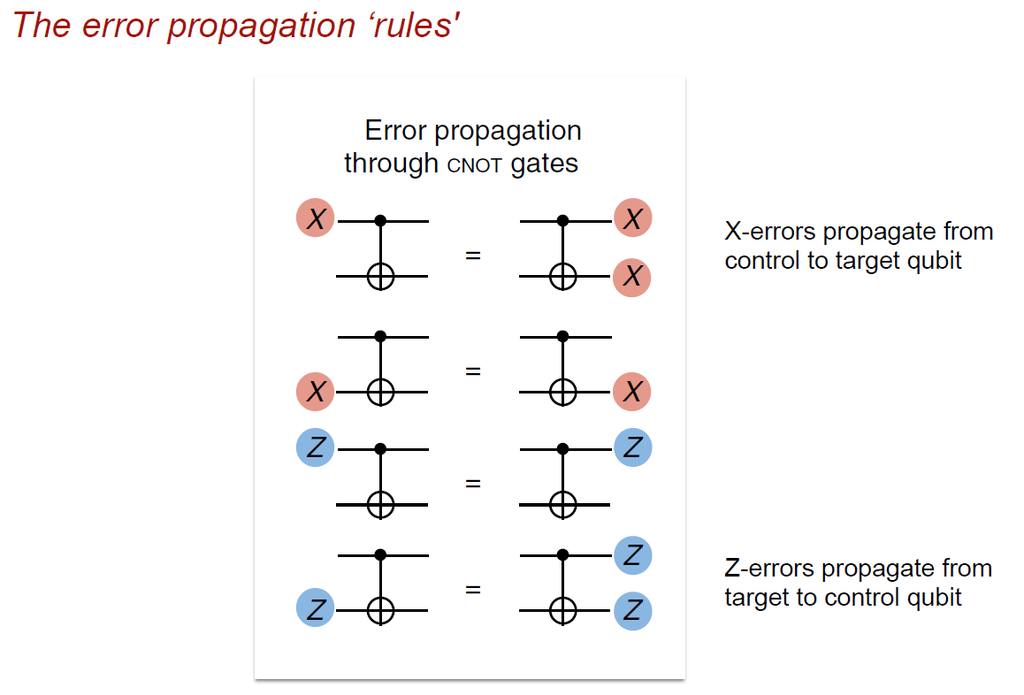

El error del que se nos habla es el siguiente:

```
Medidas de los estabilizadores: 000000
```

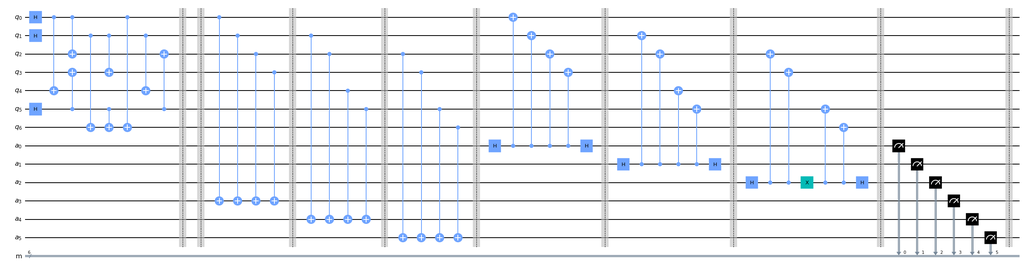

Este error se puede propagar como hemos visto, y el resultado es el siguiente:

```
Medidas de los estabilizadores: 000000
```

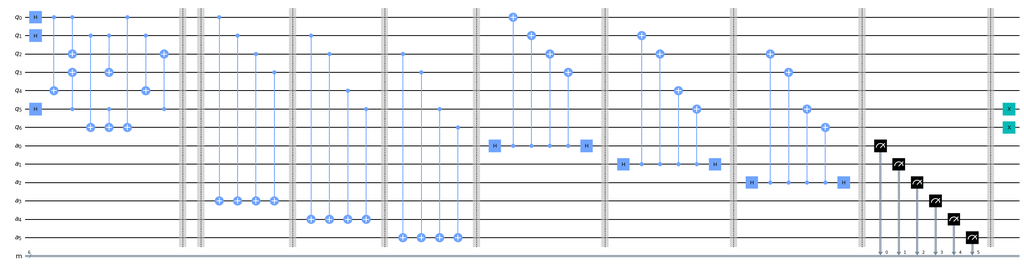

Como podemos ver, un error de este tipo se propaga por el circuito y, en este caso en el que ni siquiera hemos considerado un error en los qubits del código, acaba siendo equivalente a dos errores de tipo $X$ en el código al final del proceso de corrección de errores. Como hemos visto en el apartado anterior, este tipo de error en 2 qubits no podría ser corregido si se repite el proceso de corrección de errores. Por tanto, el código de Steane falla incluso con solo un error ocurriendo en la parte del circuito encargado de corregir errores.

Este problema es la motivación del campo de corrección de errores cuánticos resistente a fallos (fault-tolerant QEC), que utiliza circuitos mas complejos con qubits adicionales para asegurarse de proteger al qubit lógico de errores que aparezcan tanto en los qubits físicos como durante el proceso de corrección de errores en sí.

## Donaciones

Puedes donar una vez en el siguiente enlace (Ko-Fi):  
*Click en la imagen.*

[figure not shown]